# Data Summary

Team1 - Bryton Levalley, Emma Johnson, Jessica Hosler, Minju Lee, Routhana Long

February 21, 2020

## Data flow Diagram

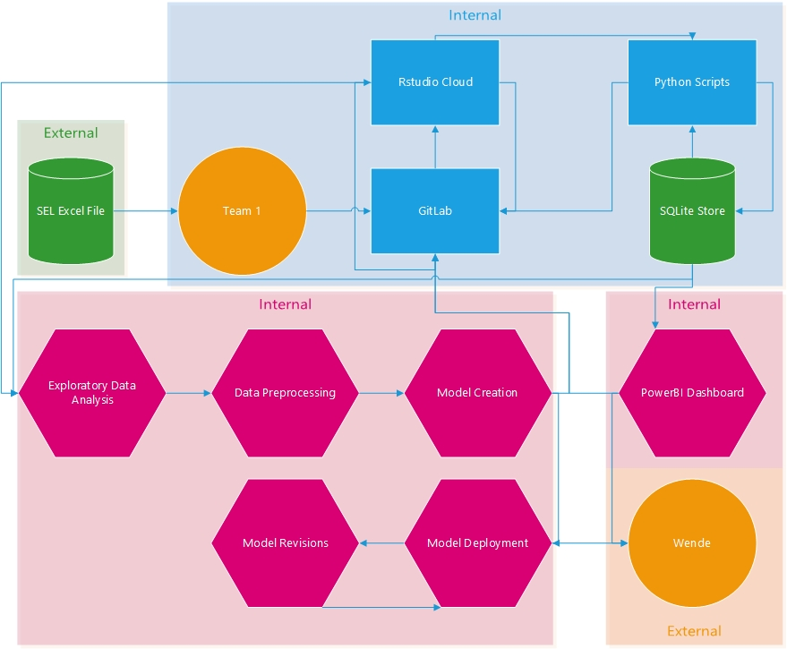

SEL DFD Diagram

## Where the Data Came From

The data comes from SEL(Schweizer Engineering Laboratories), It contains three years of raw data for 100 customers of vareid sizes. The information we are working on is fictitious, due to confidentiality of the data.

## Special Properties of the Data

Our dataset contains SEL customer orders for three years and is displayed over five tables. -The first table is “Customer Info” which has data for overall customer ID which represent the customer’s overall place in which that customer became a customer with SEL, the customer ID numbers which is the identity number for that customer, and customer size. The customer sizes have several levels ranging from -1 to 27. -Table two is “Table A” which contains data on customer location ID numbers, date order was placed, and order type. Order type is a numeric value that is either 0 or 1 which indicated order types A or B respectively. -The third table is “Table B” which contains order status information. This has customer ID numbers, order dates, the total number of items ordered, and then the number of items that were received by the customers early, on time, and late. -Table four is “Table D” which is similar to Table A, the only difference is that this table gives customer ID numbers instead of customer location ID numbers. Type values are the same as Table A as well. -The final table is “Table E” which contains company ID numbers which is the same as customer ID numbers from Table D, dates orders were placed and completed, and order type. Order type is indicated by 0 or 1 which corresponds to types A or B respectively. -Many of the tables share common column values which helps to link them to give different pieces of information about each customer order.

## Amount of Data

Customer Info: 116,158 observations with 3 values for each observation Table A: 96,230 observations with 6 values for each observation Table B: 546,963 observations, with 7 values for each observation Table D: 270,296 observations with 6 values for each observation Table E: 7,205 observations with 5 values for each observation

## Wrangling Techniques

- Date Structuring Any table with data column need to be sepereated into year, month, and day columns for the future analytics.
- Data cleaning
1. The data in Table D, ‘date’ attriute and in Table E ‘closed’ attribute include null values and missing values. In table E, There’s over 390 instances of Null or blank values of the entire 7205 observations. This means this is a large portion of the data and will require possibly some cleaning to incorporate these instances. We will most likely remove those values.

2.’Customer Size’ attribute in Customer info table includes some outliers. There is a larg amount of data with labels of 0,1,2,3 and only a single value with the label 27, and a single value with the label -1. This will require further discovery and communication with Wende to understand what this data means. Before communication we can interpret this possibly to mean we have two outliers (-1 and 27) and 4 more defining levels of customer size, 0,1,2,3. This may also require cleaning if we do have outliers.

3. In given data, all the date columns are using data type POSIXct. We will convert the data type as Date.

## Storage of the Data

The data will initially be stored in data frames. As we start to clean the data and utilize different techniques to describe and predict data trends, we will store them in matrixes that are linked by common keys, foreign keys, for easy recall.